# Data Science Capstone Final Project

2023-06-06

## Algorithm Overview

1. Clean Data-set with “tm” package.
   - Make all words to lowercase
   - Remove stop-words
   - Strip the punctuation
   - Strip numeric
   - Remove additional space
2. Merge cleaned news, blog, and twitter data-set.
3. Make a 3-grams dictionary with the ‘ngram’ package.
   - we can tokenize three consecutive words with the package. It calculates the frequency of each three-grams and probability.

## Algorithm Overview (Continued)

#### 4. Remove observations with frequency 1 to reduce size of the file and improve efficiency. Generate a 3-grams dictionary.

- The file size is reduced to 25.5Mb from 446.1Mb.
- Codes can be found [here.](https://github.com/EaglesFans/Data_Science_Capstone_Final_Project/blob/main/3_grams_dictionary.Rmd)
- Size reduced data-set (df_notail) has 2,704,797 observations while 3-grams data-set (df_trigrams) has 42,081,542. It covers 6.427% of entries.
- 3-grams data-set has total of 48,326,458 frequent words while “df_notail” data-set has 8,949,713 ones. “df_notail” data-set covers 18.5% instances.

#### 5. The algorithm uses and analysizes the 3-grams dictionary to predict the next word.

## Shiny App

- My shiny App link can be found [here.](https://6qqr51-choonghoon-hyun.shinyapps.io/Data_Science_Capstone_Final_Shiny)
- Enter a word or words in the box under “Please enter some words in the box below”.

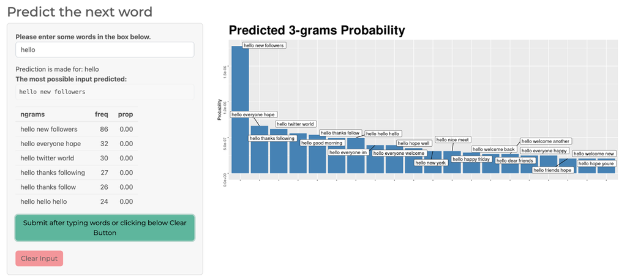

- Hit “Submit Button” to see the outcome. (You even need to click the button after clicking “Clear Input” Button.)
- Please be advised that it takes time to show you the outcome.
- You enter maximum two words because we use 3-grams dictionary to predict the next word.

## Future Project

- There are so many rows or observations with frequency of 1 (39,376,745 obs.). We removed 39,376,745 observations to achieve the efficiency. Some frequency of 1 observations are required for accuracy.
- We will make one gram variable to identify which word is more commonly used than others and incorporate it to improve our current prediction model.

### **Thank you for taking your time to enjoy this presentation.**